# 2: Basic math for statistics

Frank Edwards

# Welcome back: math time!

# Coordinates and lines

## The coordinate plane

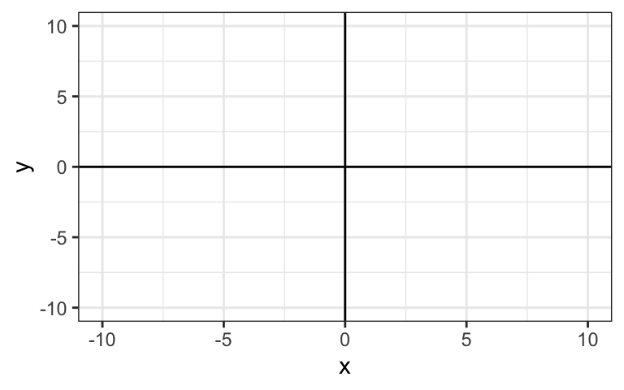

## Plotting points

For coordinate pair $(x_1,y_1)$, we can plot along an x and y axis.

## Example: (1,3)

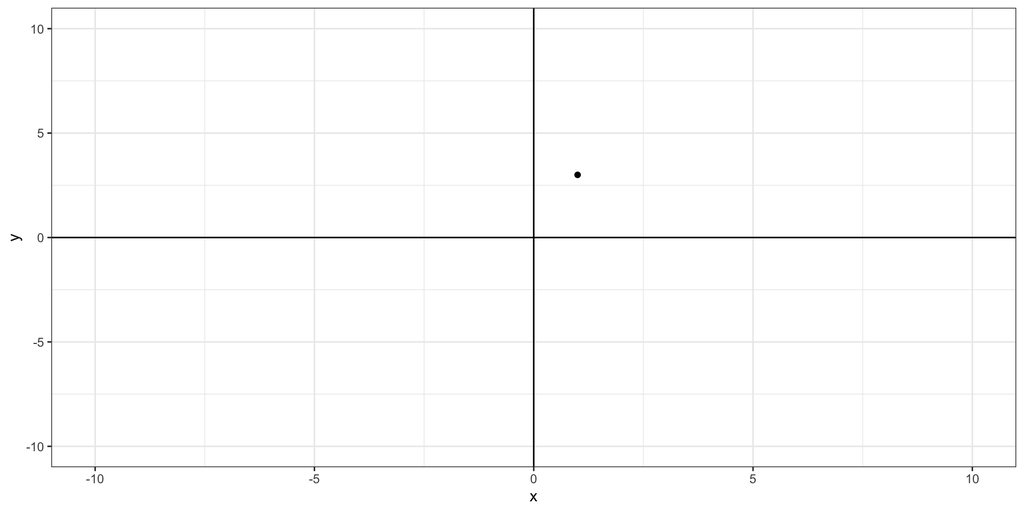

## Example: (1,3), (3,-6)

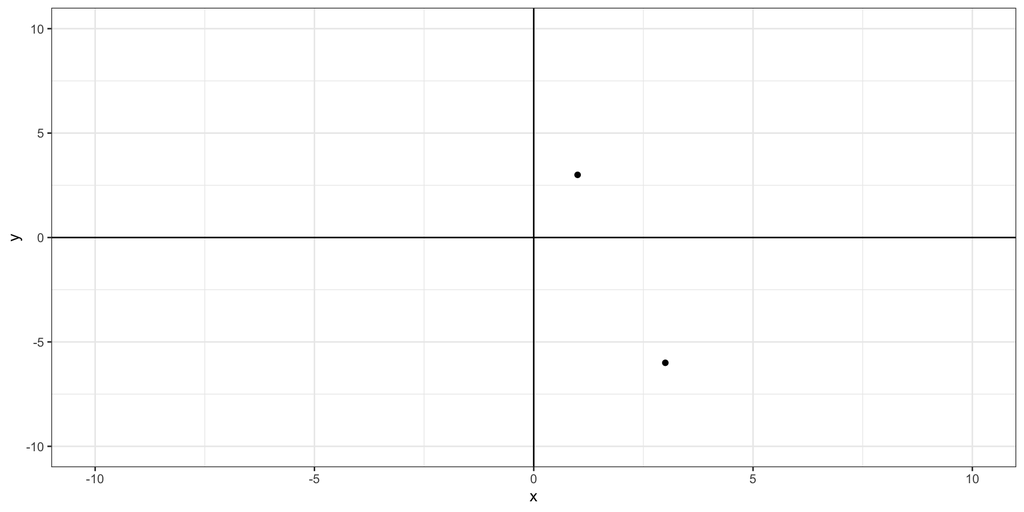

## Example: (1,3), (3,-6), (-8, -7)

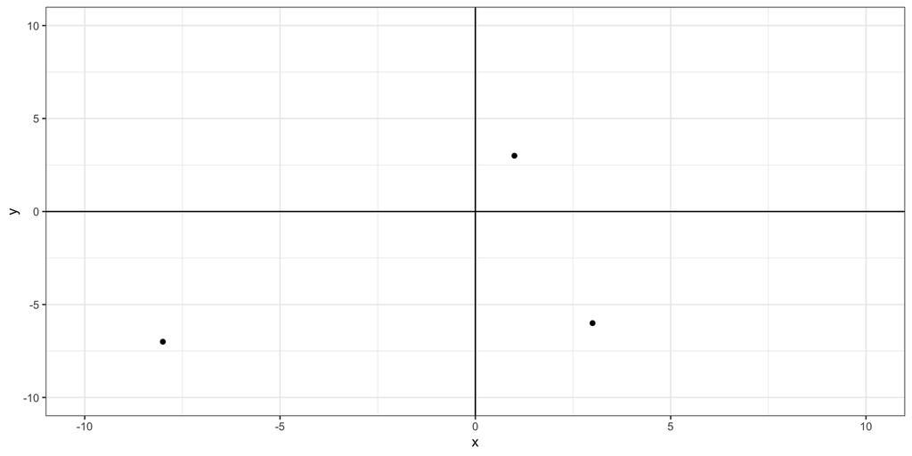

## Practice

Sketch out a coordinate plane on paper. Plot the following points.

Remember we give points as $(x,y)$, where $x$ represents the horizontal location and y represents the vertical location

- (0, 1)
- (-3, 2)
- (5, -6)
- (5, 5)

## Lines

The typical equation for a line is $y = mx + b$ where m is the slope and by is the y-intercept.

You will often see a line expressed as a regression equation:

$$y = \beta_0 + \beta_1x$$

where $\beta_0$ is the y-intercept and $\beta_1$ is the slope.

## The slope

Slope measures the steepness of a line. A line with a positive slope has increasing values of y as x increases. A line with a negative slope has decreasing values of y for increasing values of x.

We can calculate the slope with two coordinates on the line $(x_1, y_1), (x_2, y_2)$

The slope is the ratio of the difference in y values to the difference in x values.

$$m = \frac{y_2-y_1}{x_2-x_1}$$

## The y-intercept

The y-intercept is the value of y when x = 0. If we have the value of one point on the line, and the slope, we can obtain the y-intercept

$$b = y_1 - m \cdot x_1$$

## Example: intercept = 0, slope = 1

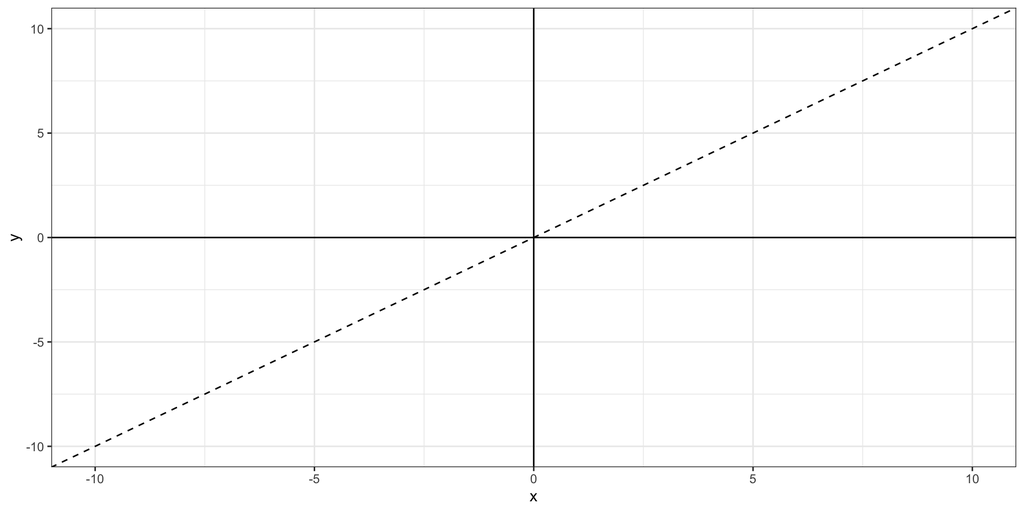

## Example: intercept = 0, slope = 0.2

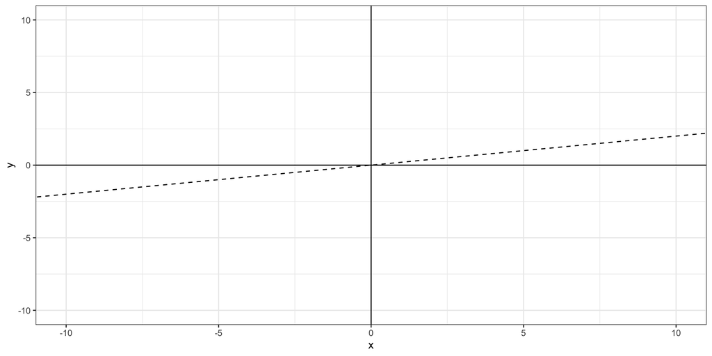

## Example: intercept = 0, slope = -1

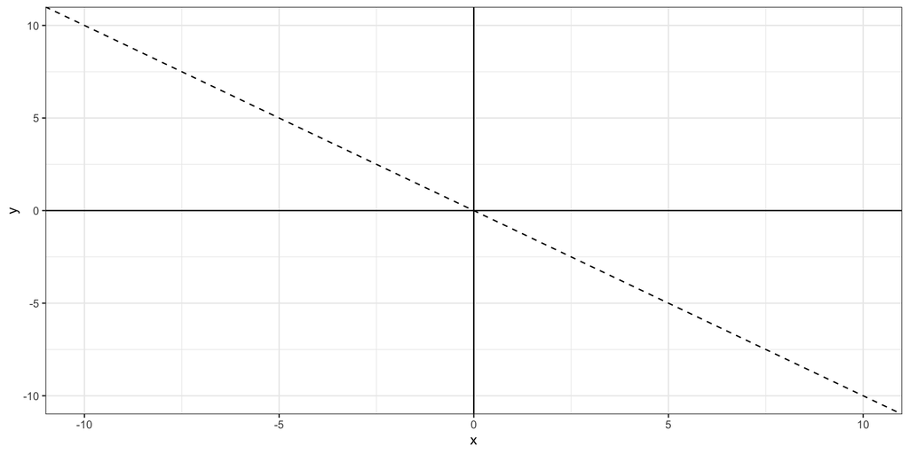

## Example: intercept = 5, slope = -1

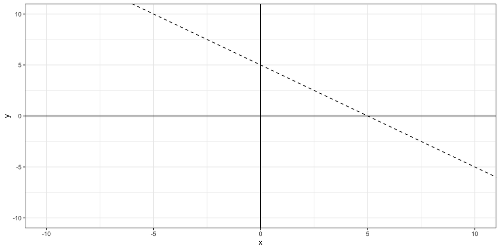

## Example: intercept = -5, slope = -1

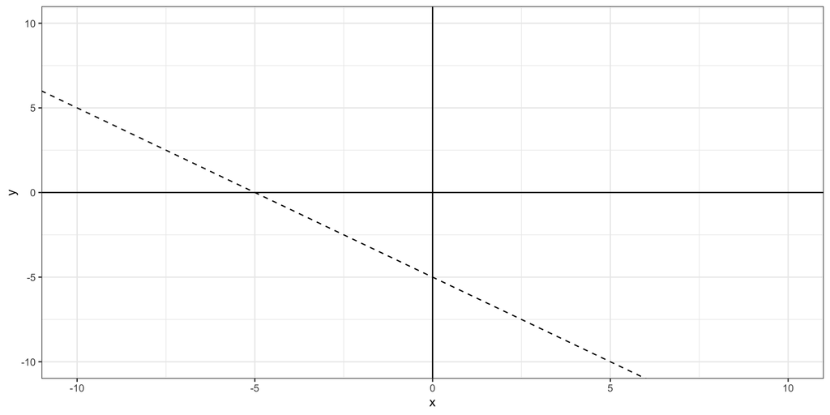

## Example

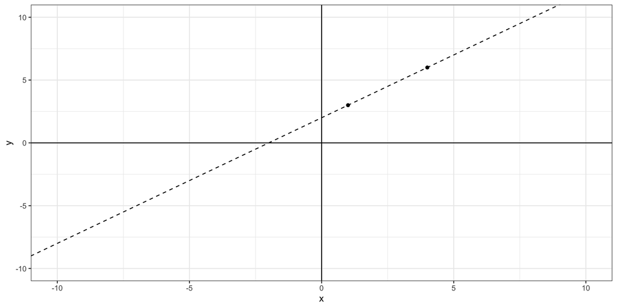

## Exercises:

**Compute slope, y-intercept, and sketch a line for each pair of coordinates**

The equation for a line is $y = mx + b$

The slope is computed as $m = \frac{y2-y1}{x2-x1}$

The y intercept is $b = y_1 - m \cdot x_1$

1. $(2,3), (5,6)$
2. $(-2,4), (0, 2)$
3. $(10, 12), (-5, -2)$

# Functions

## Functions, in general

A function maps each element in a set X to an element in set Y

- Linear function: $f(x) = x + 5$
- Quadratic function: $f(x) = x^2 + 2x + 3$
- Exponential function: $f(x) = e^{2x} + 6$

## Graphical forms of functions: linear

$f(x) = 2x + 5$

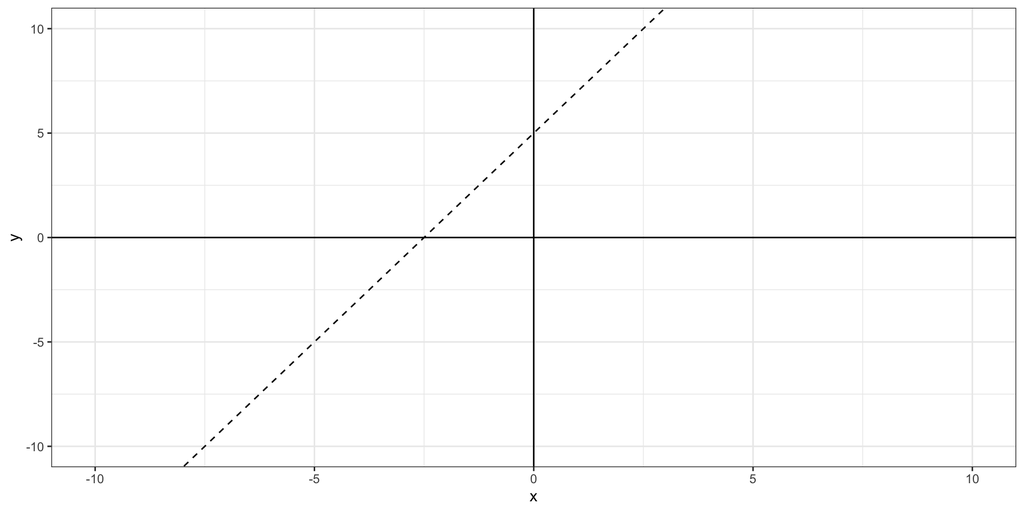

## Quadratic equations

$f(x) = x^2 + 2x + 3$

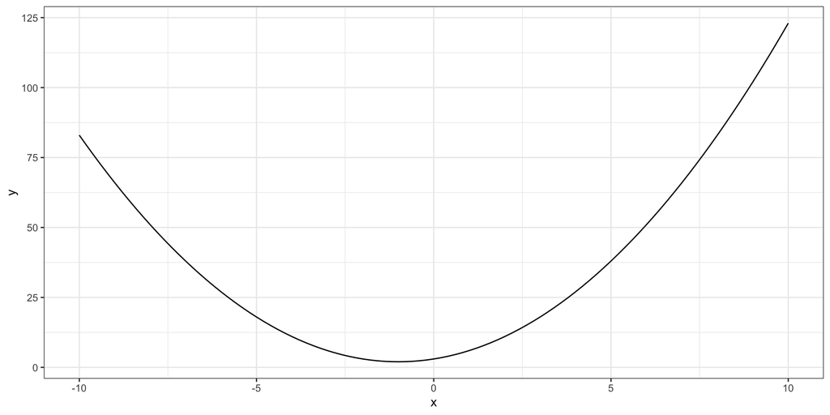

## Exponential growth

$f(x) = e^{2x} $

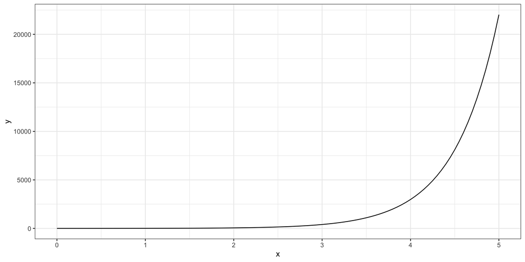

## Exponential decay

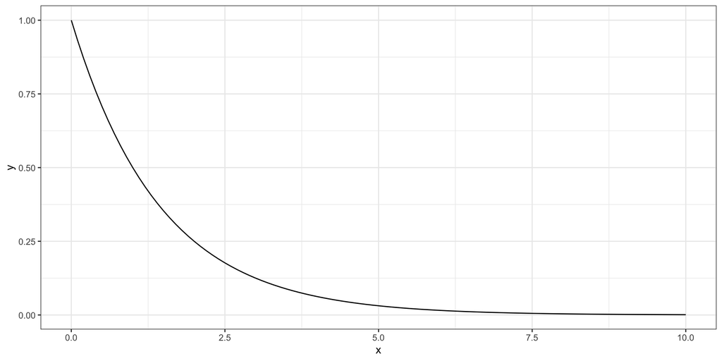

## Graphical forms of functions: logarithmic

$f(x) = log(x)$

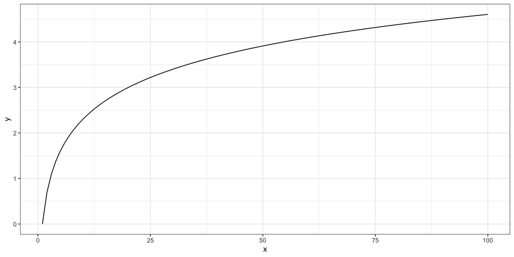

## Exercises

Evaluate these functions for $x=1$, $x=2.5$, and $x=-6$

1. $f(x) = 2x$
2. $f(x) = \frac{x}{2}$
3. $f(x) = 2(x+1)^3$

## Summation

Represented as $\sum$, with begin and end points

$$\sum_{x=1}^{3} x$$

## Summation

$$\sum_{x=1}^{3} x = 1 + 2 + 3 = 6$$

## Summation in R

In R, we can calculate a sum using the sum() function

```r
# make an integer vector from 1 to 3
x<-1:3
# x<-c(1,2,3) is equivalent
sum(x)
```

```
[1] 6
```

## Summation exercises

Compute the following by hand, and then in R

$$\sum_{x=3}^8 (x+1)$$

$$\sum_{x=1}^4 2x$$

## Exercises (solutions)

Compute the following in R

$$\sum_{x=3}^8 (x+1)$$

```r
x<-3:8 # or c(3, 4, 5, 6, 7, 8)
sum(x+1)
```

$$\sum_{x=1}^4 2x$$

```r
x<-c(1, 2, 3, 4) # or 1:4
sum(2*x)
```

# Vectors

Vectors are one-dimensional arrays of values. They have dimension $n$, where $n$ is the number of elements in the vector

$$x = \left[\begin{array}
{rrrr}
1 & 2 & 3 & 4
\end{array}\right]$$

## Indexing

We can define each element with a position index $i$.

$$x = \left[\begin{array}
{rrrr}
3 & 1 & 5 & 2
\end{array}\right]$$

- What is $x_2$?
- What is $x_4$

## Vector operations

We can compute operations on vectors using single values, called scalars. Simply perform the operation on each element of the vector

$$x = \left[\begin{array}
{rrrr}
3 & 1 & 5 & 2
\end{array}\right]$$

$$2 + x = \left[\begin{array}
{rrrr}
5 & 3 & 7 & 4
\end{array}\right]$$

$$2x = \left[\begin{array}
{rrrr}
6 & 2 & 10 & 4
\end{array}\right]$$

## Vector operations

We can compute math operations on two vectors of equal dimension by performing the operation on each element pair by index

$$x = \left[\begin{array}
{rrrr}
3 & 1 & 5 & 2
\end{array}\right]$$

$$y = \left[\begin{array}
{rrrr}
4 & -2 & 3 & 0
\end{array}\right]$$

$$x + y = \left[\begin{array}
{rrrr}
7 & -1 & 8 & 2
\end{array}\right]$$

## Exercises: compute the following

$$x = \left[\begin{array}
{rrrr}
2 & 1 & 4 & -2
\end{array}\right]$$

$$y = \left[\begin{array}
{rrrr}
0 & 5 & 3 & 8
\end{array}\right]$$

1. x + 2
2. 2y
3. x + y
4. 2x - y

## Matrices

A matrix is a rectangular array of numbers, with dimensions expressed as rows $\times$ columns

$$\mathbf{A} = \left[\begin{array}
{rrr}
1 & 2 & 3 \\
4 & 5 & 6 \\
7 & 8 & 9
\end{array}\right]$$

A is a 3 x 3 matrix

$$\mathbf{B} = \left[\begin{array}
{rrr}
1 & 2 & 3 \\
4 & 5 & 6 \\
\end{array}\right]$$
B is a 2 x 3 matrix

$$\mathbf{C} = \left[\begin{array}
{rr}
1 & 2 \\
3 & 4 \\
5 & 6
\end{array}\right]$$

C is a 3 x 2 matrix

## Matrix notation

$\mathbf{X}_{ij}$ refers to the value in the $i$th row and $j$th column of matrix $\mathbf{X}$.

$$\mathbf{X} = \left[\begin{array}
{rrr}
x_{11} & x_{12} & x_{13} \\
x_{21} & x_{22} & x_{23} \\
\end{array}\right]$$

## Matrix notation

$$\mathbf{X} = \left[\begin{array}
{rrr}
1 & 2 & 3 \\
4 & 5 & 6 \\
\end{array}\right]$$

What is

- $X_{1, 2}$
- $X_{2,1}$
- $X_{1, 3}$

## Diagonal Matrix

A diagonal matrix has zero values except on the diagonal:

$$\left[\begin{array}
{rrr}
1 & 0 & 0 \\
0 & 5 & 0 \\
0 & 0 & 9
\end{array}\right]$$

## Identity Matrix

An identity matrix is a special case of a diagonal matrix, where all values on the diagonal are equal to 1

$$\left[\begin{array}
{rrr}
1 & 0 & 0 \\
0 & 1 & 0 \\
0 & 0 & 1
\end{array}\right]$$

Diagnoal and Identity matrices are also symmetric, where all $x_{ij} = x_{ji}$. Symmetric matrices are square.

# Matrix operations

## Matrix transpose

A transpose interchanges the rows and columns of a matrix, or rotates it. The dimensions are switched, so an $n \times k$ matrix becomes a $k \times n$ matrix. We denote a transpose with a $T$

$$\mathbf{B} = \left[\begin{array}
{rrr}
1 & 2 & 3 \\
4 & 5 & 6 \\
\end{array}\right]
\mathbf{B^T} = \left[\begin{array}
{rr}
1 & 4 \\
2 & 5 \\
3 & 6 \\
\end{array}\right]$$

## Addition and subtraction

Two matrices (or vectors) can be added or subtracted only if they have identical dimensions. Then add or substract the corresponding elements of the matrices.

$$\left[\begin{array}
{rrr}
1 & 2 \\
3 & 4 \\
\end{array}\right] + \left[\begin{array}
{rrr}
5 & 6 \\
7 & 8 \\
\end{array}\right] =
\left[\begin{array}
{rrr}
1 + 5 & 2 + 6 \\
3 + 7 & 4 + 8 \\
\end{array}\right]$$

## Multiplication by scalar

Matrices and vectors can be multiplied by constant values (called scalars).

$$\mathbf{B} = \left[\begin{array}
{rrr}
1 & 2 & 3 \\
4 & 5 & 6 \\
\end{array}\right]
4\mathbf{B} = \left[\begin{array}
{rrr}
4 & 8 & 12 \\
16 & 20 & 24 \\
\end{array}\right]$$

$$\mathbf{C} = \left[\begin{array}
{r}
1 \\
2\\
3\\
4\\
\end{array}\right]
3\mathbf{C} = \left[\begin{array}
{r}
3 \\
6\\
9\\
12\\
\end{array}\right]$$

# Matrices and vectors in R

## The c() function makes a vector

We can define a vector in R using the `c()` function

```r
x <- c(3, 5, 8)
x
```

```
[1] 3 5 8
```

## Vector indexing in R

We can call a vector index $i$ using brackets

```r
x
```

```
[1] 3 5 8
```

```r
x[1]
```

```
[1] 3
```

```r
x[3]
```

```
[1] 8
```

## Operations on vectors

We can also easily perform scalar operations on vectors.

Try the following

- $x+2$
- $2x$
- $(x+2)^2$

## Further vector operations

In R, define $x = [1, 4, 6, 9]$ and $y = [0, -2, 5, 7]$

Compute:

- $x + y$
- $2x - y$
- $(2x+2)\times(y-3)$

## Making a matrix

```r
Z<-matrix(data = c(1, 2, 4, 5, 6, 7, 8, 9),
          nrow = 4, ncol = 2)

Z
```

```
     [,1] [,2]
[1,]    1    6
[2,]    2    7
[3,]    4    8
[4,]    5    9
```

- What is $Z_{2, 2}$?
- What is $Z_{4, 1}$?

## Matrices are made up of vectors

Bracket notation in R gets us thinking in vectors.

- Try this code `Z[,1]`. What does that return? What kind of object is it?
- What do you think you will get if you run `3 + Z[,2]`

## Exercises

```r
Z
```

```
     [,1] [,2]
[1,]    1    6
[2,]    2    7
[3,]    4    8
[4,]    5    9
```

- How could you retrieve the 3rd row of Z in R?
- Multiply the 1st column of R by 2